# Sentiment analysis on the title of movies tested to the Bechdel test

Coraline Guignard

2022-12-15

# introduction

## The Bechdel test’s history

In audiovisual works, there are marked inequalities and discrimination. For instance in cinema industry, there is an underrepresentation of women. Indeed, for each woman per film, there are 3 male characters (Micic 2015). It influences the stereotype that considers women as not important or invisible because the media are involved in the construction of the social word on gender (Micic 2015). Because of this issue, test like the Bechdel test has been created. Created by Alison Bechdel in 1985, The test Bechdel is defined in this way :

> > > «The Bechdel Test gives films a pass or fail rating based on three linked criteria: “One, it has to have at least two women in it who, two, talk to each other about, three, something besides a man.” » (Selisker 2015, 505)

However, even with these objections, the movies that pass the Bechdel test seem to have a different effect than the ones that did not pass. In the content of films, it seems to, in comparison to movies that did not pass the test, the ones that pass are more centrally connected women. (Agarwal et al. 2015). It seems also to have a practical effect on social media. The trailers that did not seem to pass the Bechdel test seem more popular, but the female users share more of the ones that pass the Bechdel test. One of the reasons could be either fiction influencing behavior and gender bias or the contrary or a combination of both (Garcia, Weber, and Garimella 2014) Whatever the right mechanism, reality, and fiction seem to be related, and evidence can be found on both sides. For this reason, it would be still relevant to study artworks through the Bechdel rule.

### Impact of the title of movies

The title is one of the things that are visible to the spectator before they see the film. Even if what advantages a movie is often the fame of the director and cast that goes with a big budget, the title of the movie is also a way to make the movie more interesting. Indeed, their effect has been studied, and an informative title would have more impact in the first weeks of release (Bae and Kim 2019). So, this could imply that title of the movie reflected a part of the content. Nevertheless, The research on the impact of the movie’s title is still low (Bae and Kim 2019). Studies about the Bechdel movie’s title do not does not contradict.this observation. For this reason, I cannot precise my assumption about the impact of the title of Bechdel movies and my study will be only descriptive.

## Gender stereotype in sentiment

Gender stereotypes can be understood through the social role Theory which is the idea that the inequality of gender is shaped by their roles in society. For this reason, « Media most often represent boys and men as active, adventurous, powerful, sexually aggressive, and largely uninvolved in human relationships, and represent girls and women as young, thin, beautiful, passive, dependent, and often incompetent » (Micic 2015, 21). On this way, on one hand, sentiments are also related to gender stereotypes (Bhaskaran and Bhallamudi 2019). For example, in politics, the moral and behavioral, and physical aspects have stronger negative sentiments on online news outlets than men (Brugnoli, Simone, and Delmastro 2022). The importance of emotion does not perceive the same between gender. Indeed, women seem to be emotional while men would be rational (Garcia, Weber, and Garimella 2014). It is observed in scientific talks like TED Talks where the comment was more personal and emotional when the presenter was a woman (Amarasekara and Grant 2019). On the other hand, some specific emotions would be more “male” and some would be more “female”. For example, we predict that men will be more angry, scared, and sad and women having more positive emotions (Kiritchenko and Mohammad 2018). Gender bias seems also to avoid some emotion depending on gender: for example, Women seems less show less anger than men because it would be discredited them (Breen and Barreto n.d.).

## Purpose of my research

Through this information about the Bechdel test, the title of the movie, and sentiment discriminated through gender, my question of the research is “Does the result of the Bechdel test have an impact on the presence of sentiment on the title of the movie ?” As the movie that passes the Bechdel test is assumed to represent women better, it could include more female aspect stereotypes in opposite to the films that did not pass where male aspect stereotypes would be more present. Since the title of the movie can be informative, hypnotically, it could be influenced by the importance of the female character for the ones that pass the Bechdel test. As it was observed, some sentiments can be more present with movies that did not pass the test and others more present with the ones that passed it. The null hypothesis is there is no significant difference between the mean of sentiment between the movie that did not pass the Bechdel test and the ones that pass it. The alternative hypothesis is there is a significant difference between the mean of sentiment between the movie that did not pass the Bechdel test and the ones that pass it. My prediction is that the alternative hypothesis will be accepted.

# method

## collecting data

The dataset is from the website [bechdeltest.com](https://bechdeltest.com/). It is still active and news films continue to be added. When I use this data set, it contained 9630 movies from 1874 to 2022. The rating assignment is made by the visitors. It is possible to contest the rates and a webmaster will be updated by sets flag. So the limitation of this data set is the subjectivity of the rater even the continuous feedback since the way everyone rates can be different since some movies can be ambiguous. However, the research tries to resolve it by creating an automatic Bechdel test see [Lakhotia, Nagesh, and Madgula (2019)](https://arxiv.org/ftp/arxiv/papers/1907/1907.03702.pdf)

## modeling data

I use some r packages:

- ggplot2
- dplyr
- tidyverse
- tada.table
- dtidytext

For my study, I used the lexical approach which identifies the sentiment of a word by building a lexicon (a dictionary of sentiment) and mapping words to it.

There are several kinds of sentimental lexicon. The one I used for this experiment is [nrc](https://nrc.canada.ca/en/research-development/products-services/technical-advisory-services/sentiment-emotion-lexicons).

I did two tests. For both of them, I had to modify my data table. I selected the column of titles according to their rank on the Bechdel test. Then I used the unnest_tockens() function to differentiate each word from the titles so that I could analyse each word separately. Then I used the inner_join() function to take only the words. Indeed, if I hadn’t done this, as the words follow the [tac] rule, there would be words with no sentimental meaning like “of” or “the” which would have made the results confusing. After modelling my data table, my first step is to compare the frequency of words between the film titles that passed the bechdel test and the others. I separated the ones that didn’t pass the test into 3 rankings “0”, maximum 1 woman, “1”, two women but not talking, “2”, two women talking but only men. So I counted the number of words per rating, then I made the proportion for each of them. Finally, I did a correlation test to check the observable finding on the graph. For the second experiment, I wanted to analyse precisely which feelings were involved in the different levels of the bechdel test result. I therefore used the same group separation as for my first test. This time I used the summarize() function, grouping the different words by sentiment to find out how many words use a certain sentiment.

# result

For the frequency experimentation :

Pearson’s product-moment correlation

Comparaison between rating “0” and pass : t = 14.258, df = 222, p-value < 2.2e-16 alternative hypothesis: true correlation is not equal to 0 95 percent confidence interval: 0.6161450 0.7541245 sample estimates: cor 0.6913872

Comparaison between rating “1” and pass : t = 17.8, df = 324, p-value < 2.2e-16 alternative hypothesis: true correlation is not equal to 0 95 percent confidence interval: 0.6436841 0.7541674 sample estimates: cor 0.7031451

Comparaison between rating “2” and pass : t = 12.738, df = 204, p-value < 2.2e-16 alternative hypothesis: true correlation is not equal to 0 95 percent confidence interval: 0.5818459 0.7353939 sample estimates: cor 0.6656055

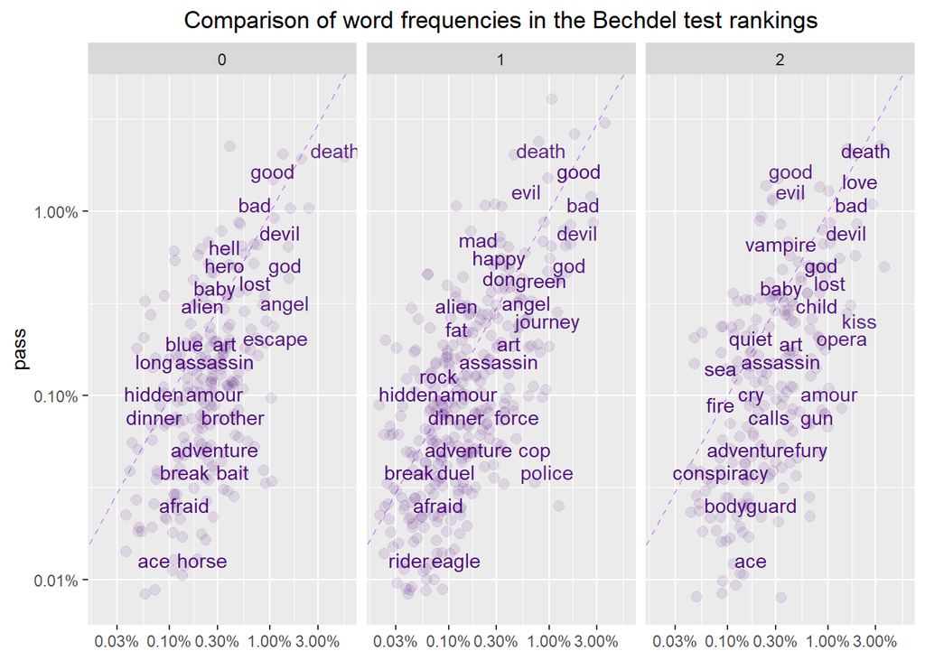

The plot’s code is from the website [tidytextmining.com](https://www.tidytextmining.com/tidytext.html)

The plot’s code is from the website [datacamp.com](https://www.datacamp.com/tutorial/sentiment-analysis-R)

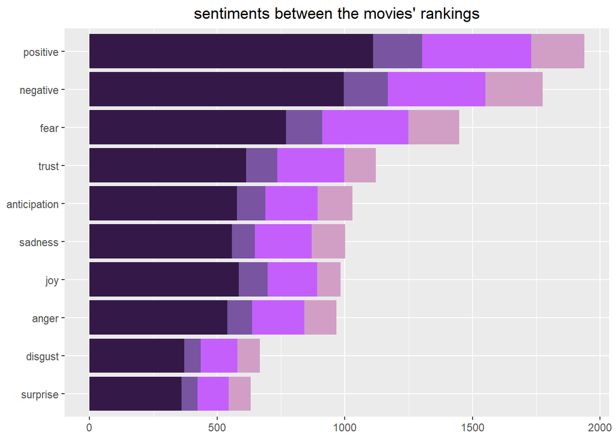

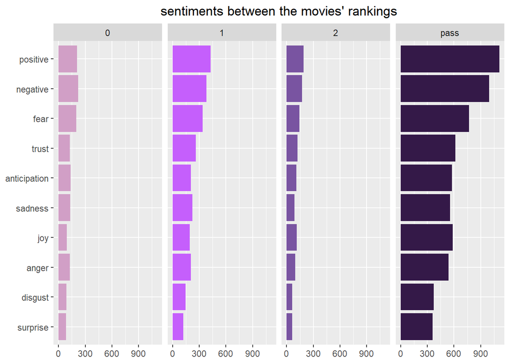

# Discussion

## conclusion

With these two tests, we therefore notice that there does not seem to be any significant differences between the feelings found in the titles of the films that pass the Bechdel test and those that do not. This does not contradict the results of the previously cited articles, as none of them provided a clear prediction on my research question.

## Limitation

### State of art

I do not find precise information about the subject of sentiment analysis for the title of movies that were tested to the Bechdel test. So, I directed my study with numerous typical assumptions.

### Data set

It is a big generalization because the movies are also constructed differently depending on the budget. For example, with low promotional budgets having an informative title is important (Bae & Kim, 2019). but not for a blockbuster my analysis was only focused on the factor of rating in the Bechdel test.

### nrc package

There are several lexicons of feeling and constructed in different ways. For example, some lexicons will focus on putting scales between negative and positive instead of defining a feeling. Others will use other feelings and even those that use the same classification are not necessarily the same. Indeed, the ratio of words that can be defined positively and words that can be defined negatively and other elements of the classification, can be different and therefore we do not get the same results depending on which one is used

### further direction

It would be interesting to observe if there is more sentiment words in bechdel test since the stereotype is also woman are consider as more emotional.

# bibliography

Agarwal, Apoorv, Jiehan Zheng, Shruti Kamath, Sriramkumar Balasubramanian, and Shirin Ann Dey. 2015. “Key Female Characters in Film Have More to Talk About Besides Men: Automating the Bechdel Test.” In *Proceedings of the 2015 Conference of the North American Chapter of the Association for Computational Linguistics: Human Language Technologies*, 830–40. Denver, Colorado: Association for Computational Linguistics. https://doi.org/10.3115/v1/N15-1084.

Amarasekara, Inoka, and Will J Grant. 2019. “Exploring the YouTube Science Communication Gender Gap: A Sentiment Analysis.” *Public Understanding of Science* 28 (1): 68–84. https://doi.org/10.1177/0963662518786654.

Bae, Giwoong, and Hye-jin Kim. 2019. “The Impact of Movie Titles on Box Office Success.” *Journal of Business Research* 103 (October): 100–109. https://doi.org/10.1016/j.jbusres.2019.06.023.

Bhaskaran, Jayadev, and Isha Bhallamudi. 2019. “Good Secretaries, Bad Truck Drivers? Occupational Gender Stereotypes in Sentiment Analysis.” arXiv. http://arxiv.org/abs/1906.10256.

Breen, Jolien A. van, and Manuela Barreto. n.d. “Mind the Gap! Stereotype Exposure Discourages Women from Expressing the Anger They Feel about Gender Inequality.” *Emotion*. Accessed December 9, 2022. https://doi.org/10.1037/emo0000810.

Brugnoli, Emanuele, Rosaria Simone, and Marco Delmastro. 2022. “Gender Stereotypes in the Mediated Personalization of Politics: Empirical Evidence from a Lexical, Syntactic and Sentiment Analysis.” arXiv. http://arxiv.org/abs/2202.03083.

Garcia, David, Ingmar Weber, and Venkata Garimella. 2014. “Gender Asymmetries in Reality and Fiction: The Bechdel Test of Social Media.” *Proceedings of the International AAAI Conference on Web and Social Media* 8 (1): 131–40. https://doi.org/10.1609/icwsm.v8i1.14522.

Kiritchenko, Svetlana, and Saif M. Mohammad. 2018. “Examining Gender and Race Bias in Two Hundred Sentiment Analysis Systems.” arXiv. http://arxiv.org/abs/1805.04508.

Lakhotia, Raghav, Chandra Kanth Nagesh, and Krishna Madgula. 2019. “Identifying Missing Component in the Bechdel Test Using Principal Component Analysis Method,” May. https://doi.org/10.5281/zenodo.3299335.

Micic, Zorana. 2015. *Female Interactions on Film - Beyond the Bechdel Test: A Quantitative Content Analysis of Same-Sex-Interactions of Top 20 Box Office Films*. http://urn.kb.se/resolve?urn=urn:nbn:se:su:diva-118209.

Selisker, Scott. 2015. “The Bechdel Test and the Social Form of Character Networks.” *New Literary History* 46 (3): 505–23. https://doi.org/10.1353/nlh.2015.0024.

“What ‘The Bechdel Test’ Doesn’t Tell Us: Examining Women’s Verbal and Vocal (Dis)empowerment in Cinema.” n.d. Accessed December 8, 2022. https://www.tandfonline.com/doi/epdf/10.1080/14680777.2016.1234239?needAccess=true&role=button.